# CS01 - Youth Disconnection

Kevin Pham, Steve Kuk, Brandon Vazquez-Tellez

## Background/Introduction

In this case study, we examined the disparities in Youth connection, which is classified as people from the ages 16-24 who are not going to school or working. In lecture, we examined the importance of this data, citing that “people who experience a period of disconnection as young adults go on to earn less and are less likely to be employed.” We wanted to further explore this topic and inspect whether gender and ethnicity had an effect on the disconnected youth. We were able to pull the data from a previous case study “Disparities in Youth Disconnection (See below for reference) which comes from the ACS (American Community Survey), conducted by the US Census Bureau.

References: “Wright, Carrie and Ontiveros, Michael and Jager, Leah and Taub, Margaret and Hicks, Stephanie C. (2020). https://github.com/opencasestudies/ocs-youth-disconnection-case-study. Disparities in Youth Disconnection.”

### Load packages

```r
#load packages
library(OCSdata)
library(tidyverse)
library(pdftools)
library(tesseract)
library(magick)
library(knitr)
library(broom)
library(tidymodels)
```

## Question

What is the relative effect of gender on percentage across race ethnicity in the United States?

## The Data

### Data Import

First we need to import the data. Since the data comes in the forms of images, we need to extract the data from the images and save all that data in a single file.

```r
#load_raw_data("ocs-bp-youth-disconnection", outpath = '.')
pdf_tools_example <-
  pdftools::pdf_text("data/raw/Making_the_Connection.pdf")

#major group data
major_racial_ethnic_groups <-
  magick::image_read("data/raw/Major_ethnic_groups_screenshot.png")
major_groups <- magick::image_ocr(major_racial_ethnic_groups)

#asian data
asian_sub_2017 <- image_read("data/raw/asian_subgroups_2017.png")
asian_sub_2017_A <- image_read("data/raw/asian_sub_2017_A.png")
asian_sub_2017_B <- image_read("data/raw/asian_sub_2017_B.png")
asian_sub_2017_C <- image_read("data/raw/asian_sub_2017_C.png")
asian_sub_2017 <- image_ocr(asian_sub_2017)
asian_sub_2017_A <- image_ocr(asian_sub_2017_A)
asian_sub_2017_B <- image_ocr(asian_sub_2017_B)
asian_sub_2017_C <- image_ocr(asian_sub_2017_C)

#latinx data
latinx_imageA <- image_read("data/raw/latinx_sub_2017_A.png")
latinx_imageB <- image_read("data/raw/latinx_sub_2017_B.png")
latinx_imageC <- image_read("data/raw/latinx_sub_2017_C.png")
latinx_sub_2017_A <- image_ocr(latinx_imageA)
latinx_sub_2017_B <- image_ocr(latinx_imageB)
latinx_sub_2017_C <- image_ocr(latinx_imageC)

#2018 asian data
asian_sub_2018_A <- image_read("data/raw/asian_sub_2018_A.png")
asian_sub_2018_A <- image_ocr(asian_sub_2018_A)
asian_sub_2018_B <- image_read("data/raw/asian_sub_2018_B.png")
asian_sub_2018_B <- image_ocr(asian_sub_2018_B)

#2018 latinx data
latinx_sub_2018 <- image_read("data/raw/latinx_subgroups_2018.png")
latinx_sub_2018 <- image_ocr(latinx_sub_2018)

#save data
save(
  major_groups,
  asian_sub_2017,
  asian_sub_2017_A,
  asian_sub_2017_B,
  asian_sub_2017_C,
  latinx_sub_2017_A,
  latinx_sub_2017_B,
  latinx_sub_2017_C,
  asian_sub_2018_A,
  asian_sub_2018_B,
  latinx_sub_2018,
  file = "data/raw/imported_data.rda")
```

### Data Wrangling

After loading in our data, it is evident that our data is not in a usable format. We begin cleaning our first dataset by: making rows and columns, making spelling consistent, separating columns into their relevant categories, removing empty rows, and adding in variables to fill in later.

```r
#split up into rows
major_groups <- major_groups |>
  stringr::str_split(pattern = "\n") |>
  unlist() |>
  tibble::as_tibble()

#separate into columns
major_groups <-
  major_groups |>
  tidyr::separate(col = value,
                  into = c("Group", "Years"),
                  sep = "(?<=[[:alpha:]])\\s(?=[0-9])")
#make consistent capitalization
major_groups <- major_groups |>
  mutate(Group = stringr::str_to_title(Group))

#separate columns by year
major_groups <- major_groups |>
  tidyr::separate(col = Years,
                  into = c("2008", "2010", "2012", "2014", "2016", "2017"),
                  sep = " ")

#remove empty rows
major_groups <- major_groups |>
  tidyr::drop_na()

#clean up values
major_groups <- major_groups |>
  mutate(
    across(.cols = -Group,
           ~ str_remove(string = ., pattern = "\\.")),  # remove decimal points
    across(.cols = -Group, as.numeric),  # convert to numeric
    across(.cols = -Group, ~ . * 0.1)   # get our decimal point back
  )

#add in future variables to use
major_groups  <- major_groups |>
mutate(Race_Ethnicity = dplyr::recode(Group, "United States" = "All_races",
                                  "Female" = "All_races",
                                  "Male" = "All_races"),
   Race_Ethnicity = str_remove(string = Race_Ethnicity,
                               pattern = "Female|Male"))

#create a column for gender
major_groups  <- major_groups |>
  mutate(Gender = str_extract(string = Group,
                              pattern = "Female|Male")) |>
  mutate(Gender = replace_na(Gender, replace = "All"))

#reshape data and collapse columns
major_groups_long <- major_groups |>
  tidyr::pivot_longer(cols = contains("20"), # any column containing 20
                      names_to = "Year",
                      values_to = "Percent",
                      names_prefix = "Perc_") |>
  dplyr::mutate(Year = as.numeric(Year))
```

Next we created a function to automatically make rows, split the data and applied that to our Asian datasets.

```r
#function to make rows
make_rows <- function(text){
  text |>
  str_split("\n") |>
  unlist() |>
  as_tibble()
}

#apply function to Asian data
asian_sub_2017 <- make_rows(asian_sub_2017)
asian_sub_2017_A <- make_rows(asian_sub_2017_A)
asian_sub_2017_B <- make_rows(asian_sub_2017_B)
asian_sub_2017_C <- make_rows(asian_sub_2017_C)

#combine Asian data
asian_sub_2017 <- bind_rows(asian_sub_2017_A,
                            asian_sub_2017_B,
                            asian_sub_2017_C)
```

We created another function that is meant to clean the data, doing everything that we mentioned previously above for our first dataset, and then applied that function, along with the previous function, to the Asian and Latinx datasets.

```r
#create a function to clean data
clean_table <- function(table){
  table |>
    separate(col = value,
             into = c("Group", "Percentage"),
             sep =  "(?<=[[:alpha:]])\\s(?=[0-9])") |>
    drop_na() |>
    mutate(Group = str_to_title(Group)) |>
    mutate(Percentage = str_remove(string = Percentage,
                                   pattern = "\\.")) |>
    separate(Percentage, c("Percent"), sep = " ") |>
    mutate(Percent = as.numeric(Percent)) |>
    mutate(Percent = Percent * 0.1) |>
    mutate(Race_Ethnicity = recode(Group,
                                   "United States" = "All_races",
                                   "Female" = "All_races",
                                   "Male" = "All_races")) |>
    mutate(Race_Ethnicity = str_remove(string = Race_Ethnicity,
                                       pattern = " Female| Male")) |>
    mutate(Gender = str_extract(string = Group,
                                pattern ="Female|Male")) |>
    mutate(Gender = replace_na(Gender, replace = "All"))
}

#apply function
asian_sub_2017 <- clean_table(table = asian_sub_2017)
#combine Latinx data
latinx_sub_2017 <- stringr::str_c(latinx_sub_2017_A,
                                  latinx_sub_2017_B,
                                  latinx_sub_2017_C)

#fix typos
latinx_sub_2017 <- latinx_sub_2017 |>
  str_replace(pattern = "DR, Cuban Female 15.7\nPR",
              replacement = "DR, Cuban Male 15.7\nPR")


#apply functions to data
latinx_sub_2017 <- make_rows(latinx_sub_2017)
latinx_sub_2017 <- clean_table(table = latinx_sub_2017)
```

Next, we combined the datasets regarding 2018 and adjusted the previous clean_table function so that it would make a new column but keep the missing positions to be filled in at a later date, rather than dropping all the empty rows. We applied this function to the Asian data and then filled in the missing information we left open with Asian data from text. Lastly, we combined the Asian information for 2017 and 2018.

```r
#combine asian data
asian_sub_2018 <- str_c(asian_sub_2018_A, asian_sub_2018_B)

#apply function to data
asian_sub_2018 <- make_rows(asian_sub_2018)

#modified function for 2018 data
clean_table_2018 <- function(table){
  table |>
    separate(col = value,
             into = c("Group", "Percent"),
             sep =  "(?<=[[:alpha:]])\\s:\\s|\\s(?=[0-9])") |>
    mutate(Group = str_remove(string = Group,
                            pattern = ":")) |>
    drop_na() |>
    mutate(Group = str_to_title(string = Group)) |>
    mutate(Percent = str_remove(string = Percent,
                               pattern = "\\.")) |>
    mutate(Percent = as.numeric(Percent)) |>
    mutate(Percent = Percent * 0.1) |>
    mutate(Race_Ethnicity = str_replace(string = Group,
                                        pattern = "Men|Women",
                                        replacement = "missing")) |>
    mutate(Race_Ethnicity = na_if(Race_Ethnicity, "missing")) |>
    fill(Race_Ethnicity, .direction = "down") |>
    mutate(Gender = str_extract(string = Group,
                                pattern = "Men|Women")) |>
    mutate(Gender = replace_na(Gender, replace = "All"))
}

#apply function to data
asian_sub_2018 <- clean_table_2018(asian_sub_2018)
#add all asian data from text
asian_sub_2018 <- asian_sub_2018 |>
  add_row(Group = "Asian", Percent = 6.2,
          Race_Ethnicity = "Asian", Gender = "All") |>
  add_row(Group = "Asian", Percent = 6.4,
          Race_Ethnicity = "Asian", Gender = "Men") |>
  add_row(Group = "Asian", Percent = 6.1,
          Race_Ethnicity = "Asian", Gender = "Women")

#make new column for 2017 and 2018 data
asian_sub_2017 <- asian_sub_2017 |>
  mutate(Year = 2017)
asian_sub_2018 <- asian_sub_2018 |>
  mutate(Year = 2018)

#make gender information consistent
asian_sub_2018 <- asian_sub_2018 |>
  mutate(across(.cols = c(Gender, Group),
               ~ str_replace(string = .,
                             pattern = "Men",
                             replacement = "Male")),
         across(.cols = c(Gender, Group),
               ~ str_replace(string = .,
                             pattern = "Women",
                             replacement = "Female")))

#combine asian data from 2017 and 2018
asian_subgroups <- bind_rows(asian_sub_2017, asian_sub_2018)
```

We repeated the steps we took with the asian data and used the same functions and applied those to the Latinx data.

```r
#replace characters
latinx_sub_2018 <- str_replace_all(string = latinx_sub_2018,
                                  pattern = "\\s:\n{2}|\n{2}", #remove two newline characters
                                  replacement = " ")

#apply functions
latinx_sub_2018 <- make_rows(latinx_sub_2018 )
latinx_sub_2018 <- clean_table_2018(latinx_sub_2018)
#create function for fixing names
fix_latinx_naming <- function(table){
  table |>
  mutate(Group = str_replace(string = Group,
                             pattern = "Pr, Dr, Cuban",
                             replacement = "Puerto Rican, Dominican, Cuban"),
          Race_Ethnicity = str_replace(string = Race_Ethnicity,
                                       pattern = "Pr, Dr, Cuban",
                                       replacement = "Puerto Rican, Dominican, Cuban"))
}

#apply function to datasets
latinx_sub_2017 <- fix_latinx_naming(latinx_sub_2017)
latinx_sub_2018 <- fix_latinx_naming(latinx_sub_2018)

#add in latinx data from text
latinx_sub_2018 <- latinx_sub_2018 |>
  add_row(Group = "Latinx", Percent = 12.8,
          Race_Ethnicity = "Latinx", Gender = "All") |>
  add_row(Group = "Latinx", Percent = 12.3,
          Race_Ethnicity = "Latinx", Gender = "Men") |>
  add_row(Group = "Latinx", Percent = 13.3,
          Race_Ethnicity = "Latinx", Gender = "Women")

#recode gender
latinx_sub_2018 <- latinx_sub_2018 |>
  mutate(across(.cols = c(Gender, Group),
                ~ str_replace(string = ., pattern = "Men", replacement = "Male")),
         across(.cols = c(Gender, Group),
                ~ str_replace(string = ., pattern = "Women", replacement = "Female")))

#create new columns for years and combine data
latinx_sub_2017 <- latinx_sub_2017 |>
  mutate(Year = 2017)
latinx_sub_2018 <- latinx_sub_2018 |>
  mutate(Year = 2018)
latinx_subgroups <- bind_rows(latinx_sub_2017, latinx_sub_2018)

#add missing categories in data
latinx_subgroups <- latinx_subgroups |>
  select(-Group) |>
  pivot_wider(names_from = Year, values_from = Percent) |>
  pivot_longer(cols = -c(Race_Ethnicity, Gender),
               names_to ="Year" ,
               values_to="Percent")
```

We saved all of the code wrangling we did into a data file so that we wouldn’t have to re-run all this code everytime we needed to call on it.

```r
#save data
save(major_groups_long, asian_subgroups, latinx_subgroups, file = "data/wrangled_data.rda")
readr::write_csv(major_groups_long, file = "data/wrangled_major_groups_data.csv")
readr::write_csv(asian_subgroups, file = "data/wrangled_asian_subgroups_data.csv")
readr::write_csv(latinx_subgroups, file = "data/wrangled_latinx_subgroups_data.csv")
```

We loaded in the saved data so that we could easily call on this information.

```r
#load in data from now on
major_groups_long <- read.csv(file = 'data/wrangled_major_groups_data.csv')
asian_subgroups <- read.csv(file = 'data/wrangled_asian_subgroups_data.csv')
latinx_subgroups <- read.csv(file = 'data/wrangled_latinx_subgroups_data.csv')
```

## Analysis

```r
view(major_groups_long)
view(asian_subgroups)
view(latinx_subgroups)
```

Loading in and viewing the data we can see major_groups_long, asian_subgroups, latinx_subgroups. All three have similar columns that exemplify youth disconnection between genders and ethnicity. Taking into consideration the limitations; certain groups being underrepresented, it can be seen in the “exploratory data analysis” that there is a drop in percentage from the start of 2010. It is important to note that the mean and median play a crucial role in interpreting data and being able to see if the mean is higher than the median gives us insight on possible outliers.

### Exploratory Data Analysis

```r
#view statistics
major_groups_long |>
  group_by(Group) |>
  summarise(mean = mean(Percent), median = median(Percent), std = sd(Percent))
```

```
## # A tibble: 18 × 4
##    Group                   mean median   std
##    <chr>                  <dbl>  <dbl> <dbl>
##  1 Asian                   7.42   7.45 0.773
##  2 Asian Female            7.75   8    0.896
##  3 Asian Male              7.07   6.95 0.734
##  4 Black                  20.2   20.5  2.22
##  5 Black Female           17.0   17.3  2.11
##  6 Black Male             23.3   23.6  2.42
##  7 Female                 12.7   13.0  1.26
##  8 Latina Female          17.4   17.6  2.76
##  9 Latino                 15.8   16.0  2.09
## 10 Latino Male            14.2   13.8  1.80
## 11 Male                   13.2   12.8  1.39
## 12 Native American        26.0   26.0  1.79
## 13 Native American Female 25     25.0  1.27
## 14 Native American Male   27.0   27.4  2.65
## 15 United States          13.0   12.9  1.28
## 16 White                  10.4   10.2  0.945
## 17 White Female           10.2   10.4  0.813
## 18 White Male             10.6   10.4  1.12
```

```r
asian_subgroups |>
  group_by(Race_Ethnicity) |>
  summarise(mean = mean(Percent), median = median(Percent), std = sd(Percent))
```

```
## # A tibble: 11 × 4
##    Race_Ethnicity  mean median    std
##    <chr>          <dbl>  <dbl>  <dbl>
##  1 All_races      11.5   11.5   0.351
##  2 Asian           6.42   6.45  0.232
##  3 Cambodian      13.8   13.8  NA
##  4 Chinese         4.2    4.2   0.374
##  5 Filipino        7.07   7.05  0.665
##  6 Hmong          14.3   14     4.21
##  7 Indian          5.67   5.65  1.28
##  8 Korean          6      5.55  1.10
##  9 Pakistani       6.4    6.4  NA
## 10 Two Or More     6.6    6.6  NA
## 11 Vietnamese      5.88   5.9   1.60
```

```r
latinx_subgroups |>
  group_by(Race_Ethnicity) |>
  summarise(mean = mean(Percent, na.rm = TRUE), median = median(Percent, na.rm = TRUE), std= sd(Percent, na.rm =TRUE))
```

```
## # A tibble: 9 × 4
##   Race_Ethnicity                  mean median    std
##   <chr>                          <dbl>  <dbl>  <dbl>
## 1 Central American               13.0    12.8  2.41
## 2 Latina                         13.9    13.9 NA
## 3 Latino                         12.8    12.8  0.566
## 4 Latinx                         12.8    12.8  0.5
## 5 Mexican                        13.1    13.1  0.925
## 6 Other Latina                   11.5    11.5 NA
## 7 Other Latino                   14.4    14.4  1.20
## 8 Puerto Rican, Dominican, Cuban 14.4    14.6  1.18
## 9 South American                  8.14    8    0.635
```

We first took the mean and median for our data in order to see more clearly what the disparities are. Comparing the statistics, we can see a general trend where youth in the Black and Native American groups have the largest percentage of disconnection rates.

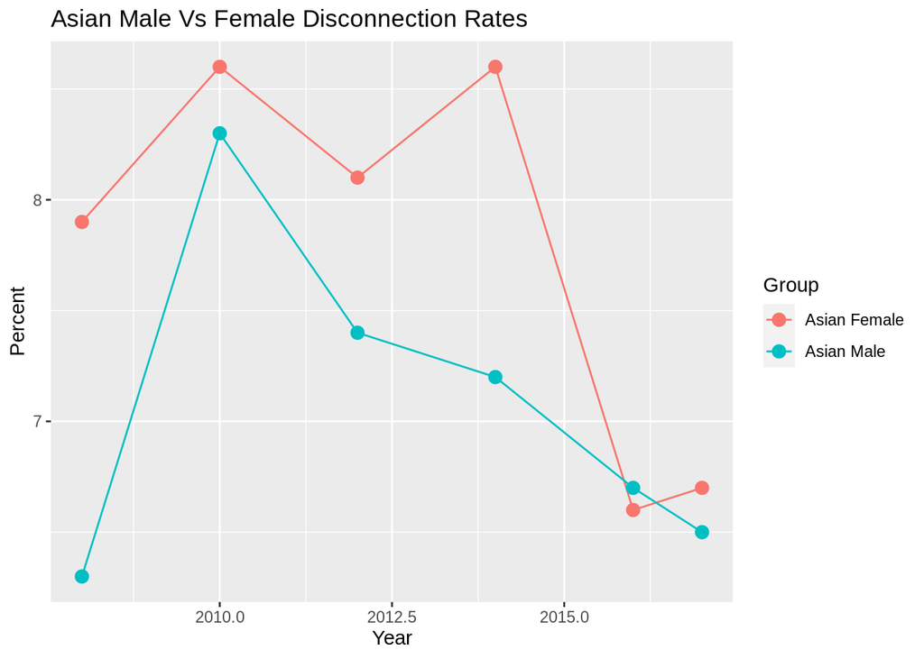

```r
#Compare asian male and female disconnection rates
major_groups_long |>
  filter(Group %in% c("Asian Male", "Asian Female")) |>
  ggplot(aes(x = Year, y = Percent, color = Group)) +
    geom_line(size = 0.5) +
    geom_point(size = 3) +
  labs(title = "Asian Male Vs Female Disconnection Rates")
```

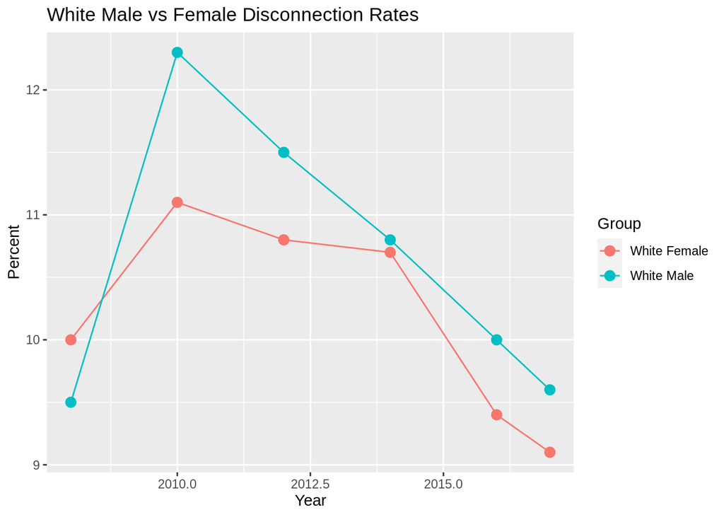

```r
#Compare white male and female disconnection rates
major_groups_long |>
  filter(Group %in% c("White Male", "White Female")) |>
  ggplot(aes(x = Year, y = Percent, color = Group)) +
    geom_line(size = 0.5) +
    geom_point(size = 3) +
  labs(title = "White Male vs Female Disconnection Rates")
```

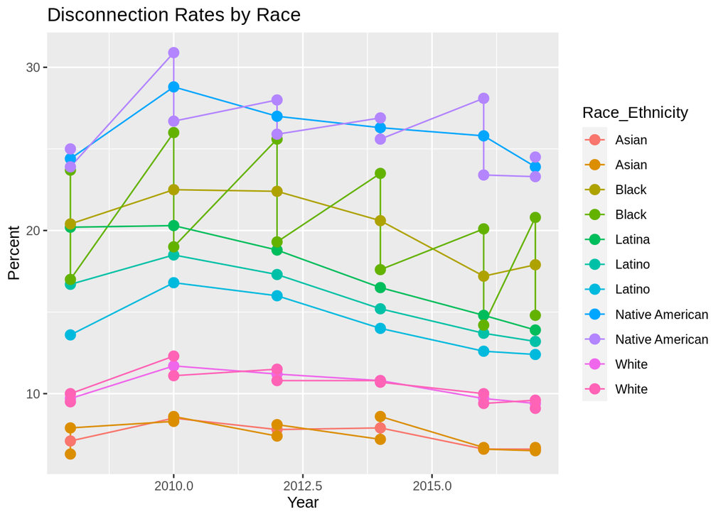

```r
#Compare disconnection rates by all races
major_groups_long |>
  filter(Race_Ethnicity != "All_races") |>
  ggplot(aes(x = Year, y = Percent, color = Race_Ethnicity)) +
    geom_line(size = 0.5) +
    geom_point(size = 3) +
    labs(title = "Disconnection Rates by Race")
```

In order to view the rate of disconnection in youth more specifically, we decided to look at the disparity between genders in different ethnic groups. First off, we’re looking at our major_groups_long data. We look at the Asian male and female disconnection rates by filtering through the data to visualize this difference. Secondly, we take White male and female data and visualize the disparity. From the graphs, we can see that Asian Females and White Males generally has higher disconnection rates over the years than their counterparts.

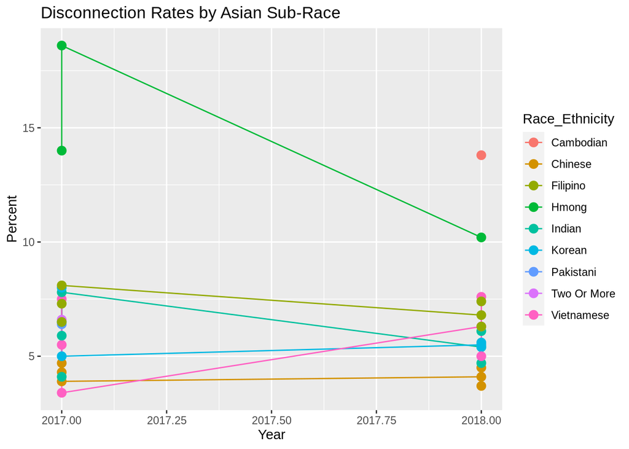

```r
#Compare disconnection rates by Asian subgroups
asian_subgroups |>
  filter(!Race_Ethnicity %in% c("All_races", "Asian")) |>
  ggplot(aes(x = Year, y = Percent, color = Race_Ethnicity)) +
    geom_line(size = 0.5) +
    geom_point(size = 3) +
    labs(title = "Disconnection Rates by Asian Sub-Race")
```

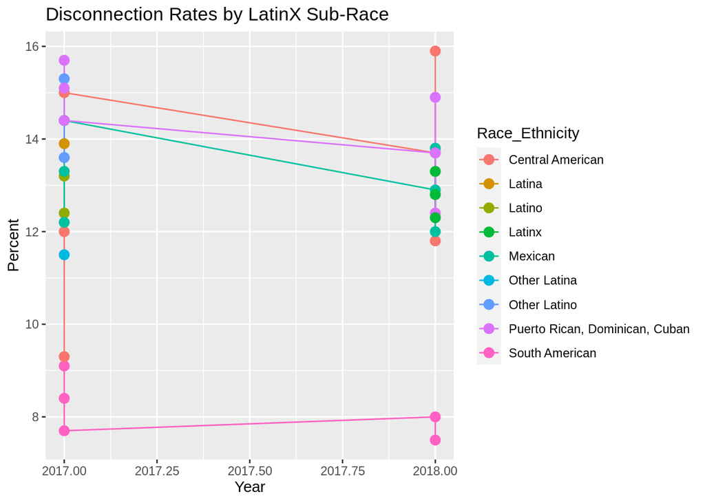

```r
#Compare disconnection rates by LatinX subgroups
latinx_subgroups |>
  ggplot(aes(x = Year, y = Percent, color = Race_Ethnicity)) +
    geom_line(size = 0.5) +
    geom_point(size = 3) +
    labs(title = "Disconnection Rates by LatinX Sub-Race")
```

Finally, we also looked into disconnection rates of between different sub-races. From the previous graph, we again see that youth that are part of the Black and Native American groups have highest disconnection percentages. Because of this, we wanted to look into specifics statistics of Asian and LatinX subgroups. Out of all the Asian subgroups, we can see that Hmong has had the highest disconnection rate until 2018. Likewise, out of all the LatinX subgroups, we see that the subgroups ‘Central American’ and ‘Puerto Rican, Dominican, Cuban’ generally has the highest disconnection rates.

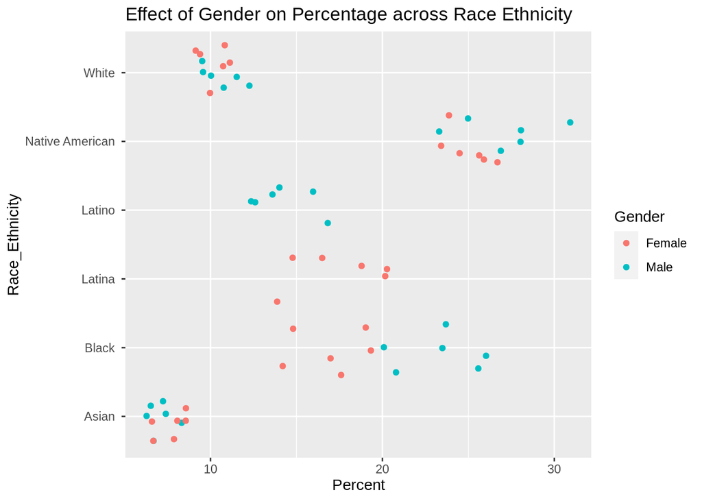

```r
major_groups_long |>
  filter(!Group %in% c("Asian", "White", "Latino", "Black", "Native American"), Gender != "All",
         Race_Ethnicity != "All_races") |>
  ggplot(aes(x = Race_Ethnicity, y = Percent, color = Gender)) +
    geom_jitter() +
    coord_flip() +
    labs(title = "Effect of Gender on Percentage across Race Ethnicity")
```

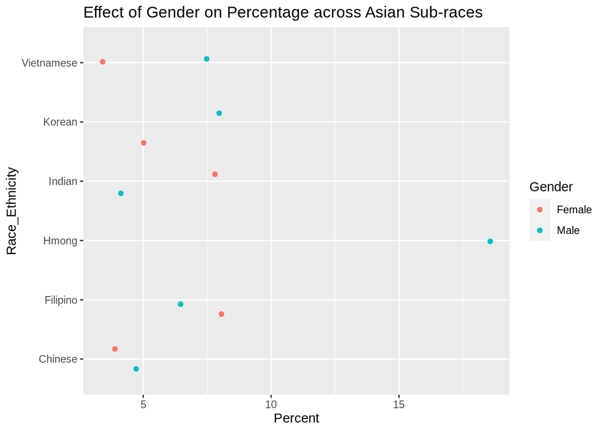

```r
asian_subgroups |>
  filter(!Group %in% c("United States", "Male", "Female"),
         Gender != "All", Race_Ethnicity != "Asian") |>
  ggplot(aes(x = Race_Ethnicity, y = Percent, color = Gender)) +
    geom_jitter() +
    coord_flip() +
    labs(title = "Effect of Gender on Percentage across Asian Sub-races")
```

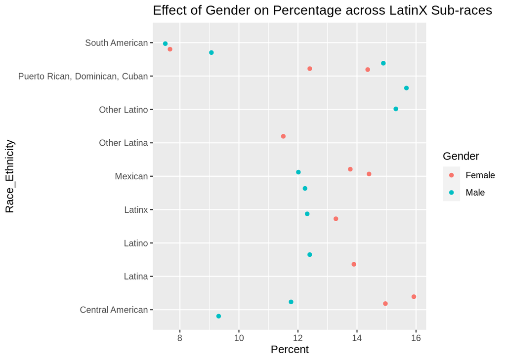

```r
latinx_subgroups |>
  filter(Gender != "All") |>
  ggplot(aes(x = Race_Ethnicity, y = Percent, color = Gender)) +
    geom_jitter() +
    coord_flip() +
    labs(title = "Effect of Gender on Percentage across LatinX Sub-races")
```

Based off of our previous results and studies, we decided to look more into how Gender affects Percentage across different race ethnicity in the United States (our question). We graphed the relationship between Gender and Percentage across the general race ethnicity then graphed the relationship of its subgroups. From the first graph, we can see that males tend to be on the higher percentages whereas females are spread across the middle to lower end of the percentages. Looking at the Asian subgroups, we again see that males tend to be on the higher percentages compared to their counterparts. Finally, looking at the LatinX subgroups, we see that there are generally more females on the higher percentages than males.

### Data Analysis

First we filtered out any information other than male and female for each ethnicity and added in the row to serve as our base percentage. Then we performed a linear regression model on the major groups dataset using the Percent and Groups.

```r
#linear regression
major_lin <- major_groups_long |>
  filter(!Group %in% c("Asian", "White", "Latino", "Black", "Native American"), Gender != "All",
         Race_Ethnicity != "All_races") |>
  add_row(Group = "AAUnited States", Race_Ethnicity = "All Races", Gender = "All", Percent = 12.97)
major_groups_long_lin <- linear_reg() |>
  set_engine("lm") |>
  fit(Percent ~ Group, data = major_lin)
```

Next we added a new column to the asian dataset for male and female for each nationality and added in a row to serve as our base percentage. Then we performed a linear regression model on the asian dataset using the Percent and Nationality.

```r
#linear regression
asian_lin_1 <- asian_subgroups |>
  mutate(Nationality = case_when(
    Gender == "Male" & Race_Ethnicity == "Chinese" ~ "Chinese Male",
    Gender == "Female" & Race_Ethnicity == "Chinese" ~ "Chinese Female",
    Gender == "Male" & Race_Ethnicity == "Vietnamese" ~ "Vietnamese Male",
    Gender == "Female" & Race_Ethnicity == "Vietnamese" ~ "Vietnamese Female",
    Gender == "Male" & Race_Ethnicity == "Indian" ~ "Indian Male",
    Gender == "Female" & Race_Ethnicity == "Indian" ~ "Indian Female",
    Gender == "Male" & Race_Ethnicity == "Korean" ~ "Korean Male",
    Gender == "Female" & Race_Ethnicity == "Korean" ~ "Korean Female",
    Gender == "Male" & Race_Ethnicity == "Filipino" ~ "Filipino Male",
    Gender == "Female" & Race_Ethnicity == "Filipino" ~ "Filipino Female",
    Gender == "Male" & Race_Ethnicity == "Hmong" ~ "Hmong Male"
  )) |>
  drop_na() |>
  add_row(Group = "United States", Race_Ethnicity = "Asian", Gender = "All", Percent = 11.5, Nationality = "AAUnited States") |>
  add_row(Group = "Asian", Race_Ethnicity = "Asian", Gender = "All", Percent = 6.4, Nationality = "Asian")
asian_lin <- linear_reg() |>
  set_engine("lm") |>
  fit(Percent ~ Nationality, data = asian_lin_1)
```

Lastly we filtered for either male or female gender and added a new column to the latinx dataset for male and female for each nationality. We then added in a row to serve as our base percentage and performed a linear regression model on the latinx dataset using the Percent and Group.

```r
latinx_lin_1 <- latinx_subgroups |>
  filter(Gender != "All") |>
  mutate(Group = case_when(
    Gender == "Male" & Race_Ethnicity == "Latino" ~ "Latino Male",
    Gender == "Female" & Race_Ethnicity == "Latina" ~ "Latina Female",
    Gender == "Male" & Race_Ethnicity == "South American" ~ "South American Male",
    Gender == "Female" & Race_Ethnicity == "South American" ~ "South American Female",
    Gender == "Male" & Race_Ethnicity == "Central American" ~ "Central American Male",
    Gender == "Female" & Race_Ethnicity == "Central American" ~ "Central American Female",
    Gender == "Male" & Race_Ethnicity == "Mexican" ~ "Mexican Male",
    Gender == "Female" & Race_Ethnicity == "Mexican" ~ "Mexican Female",
    Gender == "Male" & Race_Ethnicity == "Other Latino" ~ "Other Latino Male",
    Gender == "Female" & Race_Ethnicity == "Other Latina" ~ "Other Latina Female",
    Gender == "Male" & Race_Ethnicity == "Puerto Rican, Dominican, Cuban" ~ "Puerto Rican, Dominican, Cuban Male",
    Gender == "Female" & Race_Ethnicity == "Puerto Rican, Dominican, Cuban" ~ "Puerto Rican, Dominican, Cuban Female",
    Gender == "Male" & Race_Ethnicity == "Latinx" ~ "Latinx Male",
    Gender == "Female" & Race_Ethnicity == "Latinx" ~ "Latinx Female")) |>
  add_row(Race_Ethnicity = "Latinx", Gender = "All", Percent = 9.77, Group = "AALat") |>
  add_row(Group = "AUnited States", Race_Ethnicity = "Asian", Gender = "All", Percent = 11.5)
latinx_lin <- linear_reg() |>
  set_engine("lm") |>
  fit(Percent ~ Group, data = latinx_lin_1)
```

### Results

The following pieces of code are a result of applying linear regression to the different datasets. In order to better understand the effects of gender on percentage across race ethnicity, it is important to be able to interpret the information.

```r
#results from major groups dataset
major_groups_long_lin |> tidy()
```

```
## # A tibble: 11 × 5
##    term                        estimate std.error statistic       p.value
##    <chr>                          <dbl>     <dbl>     <dbl>         <dbl>
##  1 (Intercept)                    13.0       1.82     7.13  0.00000000372
##  2 GroupAsian Female              -5.22      1.96    -2.66  0.0105
##  3 GroupAsian Male                -5.90      1.96    -3.01  0.00414
##  4 GroupBlack Female               4.01      1.96     2.04  0.0463
##  5 GroupBlack Male                10.3       1.96     5.25  0.00000311
##  6 GroupLatina Female              4.45      1.96     2.26  0.0279
##  7 GroupLatino Male                1.26      1.96     0.643 0.523
##  8 GroupNative American Female    12.0       1.96     6.12  0.000000140
##  9 GroupNative American Male      14.1       1.96     7.16  0.00000000337
## 10 GroupWhite Female              -2.79      1.96    -1.42  0.162
## 11 GroupWhite Male                -2.35      1.96    -1.20  0.237
```

This first table displays the relationship between percentage and group for each of the different ethnicity and gender. On average, people in the United States are expected to make up 12.97 percent of the disconnected youth. The table then displays all the other ethnicity and gender in comparison to the base percentage of people in the United States who are part of the disconnected youth.

On average, Asian females are expected to make up 5.22 percent less of the disconnected youth while Asian males are expected to make up 5.90 percent less of the disconnected youth compared to the base percentage.

On average, Black females are expected to make up 4.01 percent more of the disconnected youth while Black males are expected to make up 10.31 percent more of the disconnected youth compared to the base percentage.

On average, Latina females are expected to make up 4.45 percent more of the disconnected youth while Latino males are expected to make up 1.26 percent more of the disconnected youth compared to the base percentage.

On average, Native American females are expected to make up 12.03 percent more of the disconnected youth while Native American males are expected to make up 14.06 percent more of the disconnected youth compared to the base percentage.

On average, White females are expected to make up 2.79 percent less of the disconnected youth while White males are expected to make up 2.35 percent less of the disconnected youth compared to the base percentage.

```r
#results from asian dataset
asian_lin |> tidy()
```

```
## # A tibble: 13 × 5
##    term                         estimate std.error statistic      p.value
##    <chr>                           <dbl>     <dbl>     <dbl>        <dbl>
##  1 (Intercept)                     11.5      0.786     14.6  0.0000000443
##  2 NationalityAsian                -5.1      1.11      -4.59 0.000996
##  3 NationalityChinese Female       -7.7      0.962     -8.00 0.0000118
##  4 NationalityChinese Male         -6.9      0.962     -7.17 0.0000303
##  5 NationalityFilipino Female      -3.75     0.962     -3.90 0.00298
##  6 NationalityFilipino Male        -5.1      0.962     -5.30 0.000348
##  7 NationalityHmong Male            7.1      1.11       6.39 0.0000794
##  8 NationalityIndian Female        -4.55     0.962     -4.73 0.000807
##  9 NationalityIndian Male          -7.1      0.962     -7.38 0.0000238
## 10 NationalityKorean Female        -6.3      0.962     -6.55 0.0000651
## 11 NationalityKorean Male          -4.7      0.962     -4.88 0.000639
## 12 NationalityVietnamese Female    -7.3      0.962     -7.59 0.0000187
## 13 NationalityVietnamese Male      -3.95     0.962     -4.10 0.00213
```

This second table displays the relationship between percentage and nationality for each of the different asian nationalities and gender. On average, people in the United States are expected to make up 11.5 percent of the disconnected youth while asians are expected to make up 5.1 percent less, coming in at 6.4 percent. The table then displays all the other asian nationalities and gender in comparison to the base percentage of people in the United States who are part of the disconnected youth.

On average, Chinese females are expected to make up 7.7 percent less of the disconnected youth while Chinese males are expected to make up 6.9 percent less of the disconnected youth compared to the base percentage.

On average, Filipino females are expected to make up 3.75 percent less of the disconnected youth while Filipino males are expected to make up 5.1 percent less of the disconnected youth compared to the base percentage.

On average, Indian females are expected to make up 4.55 percent less of the disconnected youth while Indian males are expected to make up 7.1 percent less of the disconnected youth compared to the base percentage.

On average, Korean females are expected to make up 6.3 percent less of the disconnected youth while Korean males are expected to make up 4.7 percent less of the disconnected youth compared to the base percentage.

On average, Vietnamese females are expected to make up 7.3 percent less of the disconnected youth while Vietnamese males are expected to make up 3.95 percent less of the disconnected youth compared to the base percentage.

```r
#results from latinx dataset
latinx_lin |> tidy()
```

```
## # A tibble: 16 × 5
##    term                                    estimate std.error statistic  p.value
##    <chr>                                      <dbl>     <dbl>     <dbl>    <dbl>
##  1 (Intercept)                                 9.77      1.02     9.55   2.90e-5
##  2 GroupAUnited States                         1.73      1.45     1.20   2.71e-1
##  3 GroupCentral American Female                5.68      1.25     4.53   2.69e-3
##  4 GroupCentral American Male                  0.78      1.25     0.622  5.53e-1
##  5 GroupLatina Female                          4.13      1.45     2.85   2.46e-2
##  6 GroupLatino Male                            2.63      1.45     1.82   1.12e-1
##  7 GroupLatinx Female                          3.53      1.45     2.44   4.48e-2
##  8 GroupLatinx Male                            2.53      1.45     1.75   1.24e-1
##  9 GroupMexican Female                         4.33      1.25     3.45   1.06e-2
## 10 GroupMexican Male                           2.33      1.25     1.86   1.05e-1
## 11 GroupOther Latina Female                    1.73      1.45     1.20   2.71e-1
## 12 GroupOther Latino Male                      5.53      1.45     3.82   6.53e-3
## 13 GroupPuerto Rican, Dominican, Cuban Fe…     3.63      1.25     2.90   2.31e-2
## 14 GroupPuerto Rican, Dominican, Cuban Ma…     5.53      1.25     4.41   3.11e-3
## 15 GroupSouth American Female                 -2.07      1.45    -1.43   1.96e-1
## 16 GroupSouth American Male                   -1.47      1.25    -1.17   2.79e-1
```

On average, Latina females are expected to make up 4.13 percent more of the disconnected youth while Latino males are expected to make up 2.63 percent more of the disconnected youth compared to the base percentage.

On average, Latinx females are expected to make up 3.53 percent more of the disconnected youth while Latinx males are expected to make up 2.53 percent more of the disconnected youth compared to the base percentage.

On average, Mexican females are expected to make up 4.33 percent more of the disconnected youth while Mexican males are expected to make up 2.33 percent more of the disconnected youth compared to the base percentage.

On average, Other Latina females are expected to make up 1.73 percent more of the disconnected youth while Other Latino males are expected to make up 5.53 percent more of the disconnected youth compared to the base percentage.

On average, Puerto Rican, Dominican, and Cuban females are expected to make up 3.63 percent more of the disconnected youth while Puerto Rican, Dominican, and Cuban males are expected to make up 5.53 percent more of the disconnected youth compared to the base percentage.

On average, South American females are expected to make up 2.07 percent less of the disconnected youth while South American males are expected to make up 1.47 percent less of the disconnected youth compared to the base percentage.

### Discussion of Results

Through the interpretations of the asian table, it is evident that overall, females make up less percentage compared to their male counterparts and base percentages within the ethnicity. An exception to this would be Filipino and Indian females who make up more percentage of the disconnected youth. It is important to note that while there are drastic decreases in percentages when comparing each of these Asian nationalities to the average person in the United States, there is very little percentage change when comparing them among other Asian nationalities. In addition, due to faulty information gathering, there was no data available for comparison for Hmong, Cambodian, pakistani, and two or more nationalities. Because of this, the previously named nationalities were left out of comparison for the genders.

The findings in the asian table were not consistent with that of the major group table because in the major group table, asian females made up more percentage of the disconnected youth compared to their male counterparts while in the asian table, asian females made up less percentage. On the other hand, the findings in the latinx table were consistent with the major group table because the females make up more percentage of the disconnected youth compared to their male counterparts.